# Analyse de Pokemons

Dylan BAPTISTE

12. avril 2020

## Introduction

Nous étudions la base de données “pokemon.csv”

Ce document ce décompose en 3 parties. Tout d’abord en une analyse globale des données, la seconde partie se concentrera sur le pokemon “Squirtle” et dans la derniere nous verons comment battre Luigia.

## Remarque

Aucune donnée erroné etait presente dans les données, aucun traitement préalable n’a donc été effectué dessus (bien qu’il manque Pikachu).

## Sommaire

### **I** Analyse globale de la base de donnée “pokemon.csv”

### **II** Presentation de mon pokemon favoris: Squirtle

### **III** Explication de comment vaincre Lugia

## **I** Analyse globale de la base de donnée

Representant un panel de 800 pokemons s’étalant de la génération 1 à 6  
Les differents types de pokemon sont: Grass, Fire, Water, Bug, Normal, Poison, Electric, Ground, Fairy, Fighting, Psychic, Rock, Ghost, Ice, Dragon, Dark, Steel, Flying

- Attaque moyenne 79.00125
- HP moyenne 69.25875
- Defence moyenne 73.8425
- Attaque special moyenne 72.82
- Defence special moyenne 71.9025
- Vitesse moyenne 68.2775

65 légendaires et 735 non légendaires.

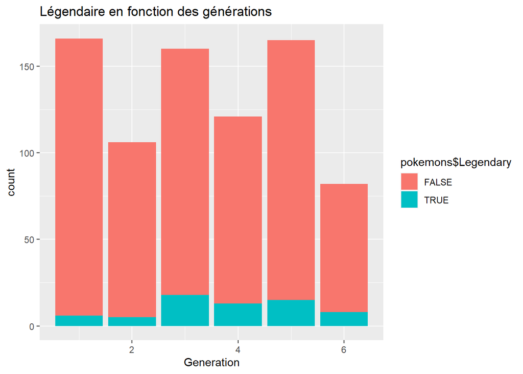

```r
ggplot(data = pokemons, aes(x=Generation)) + geom_bar(aes(fill=pokemons$Legendary)) + labs(title="Légendaire en fonction des générations")
```

Comme l’on s’y attendait les pokemon legendaires sont trés minoritaires, on remarque aussi qu’ils sont plus présent dans les générations 3 et plus que dans les 2 premières.

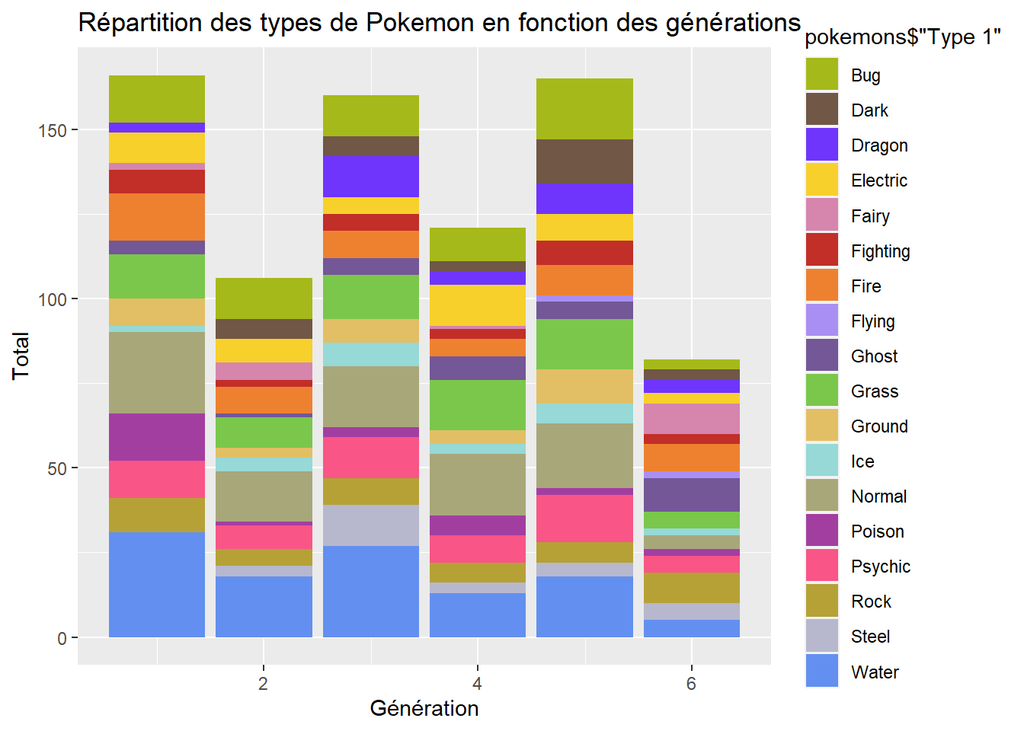

```r
ggplot(data = pokemons, aes(x=Generation)) + geom_bar(aes(fill=pokemons$"Type 1"  )) + xlab("Génération") + ylab("Total") + scale_fill_manual( values=t(t(colors_types[order(rownames(colors_types)), ]))) + labs(title="Répartition des types de Pokemon en fonction des générations")
```

On peut remarquer que la répartition reste sensiblement la même au fil des générations, aussi il semblerait que les générations paires comportent moins de nouveaux pokemons que les autres.

Voici une représentation de la répartition des types :

```r
treemap(pokemons,
        index=c("Type 1","Type 2"),
        vSize="NbType",
        type = "index",
        fontsize.labels=c(10,10),
        fontcolor.labels=c("white","gray"),
        fontface.labels=c(2,1),
        bg.labels=c("transparent"),
        align.labels=list( c("center", "center"), c("center", "center") ),
        border.col=c("black","#555555"),
        border.lwds=c(2,1),
        overlap.labels=1,
        inflate.labels=TRUE
)
```

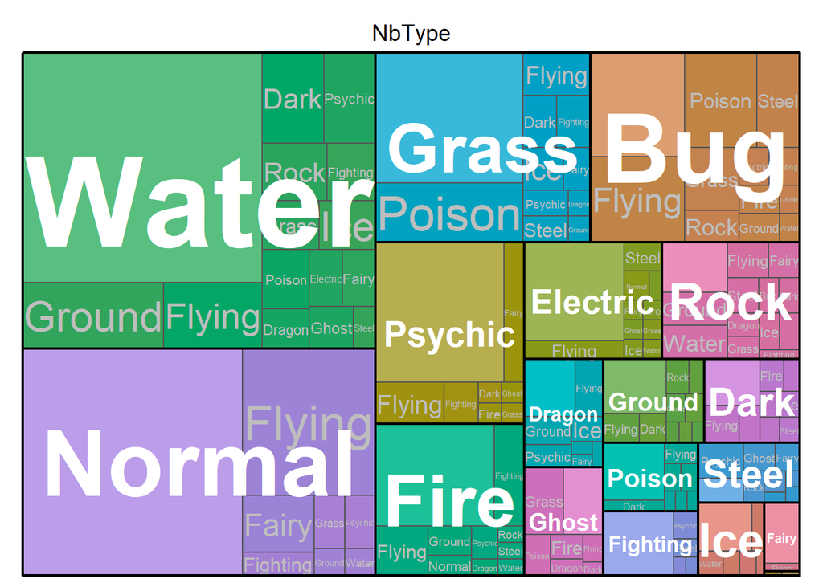

On remarque bien que le type le plus commun est Water et que le type 2 est généralement innéxistant.

Voici un graphique qui le represente mieux :

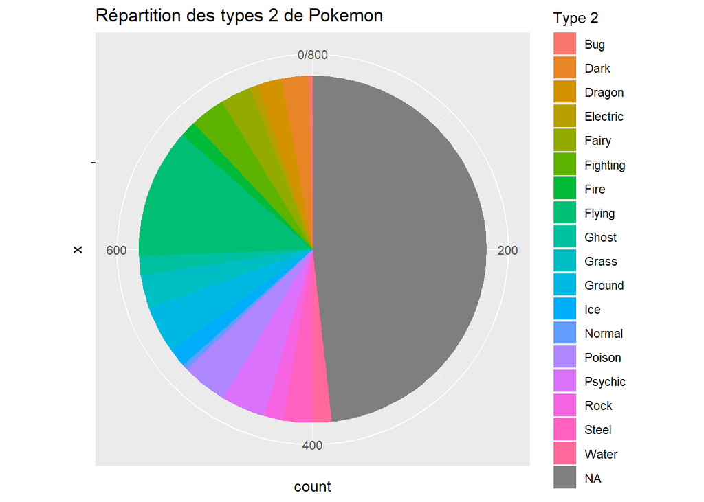

```r
ggplot(pokemons, aes(x="", fill=`Type 2`)) + geom_bar() + coord_polar("y", start=0)  + labs(title="Répartition des types 2 de Pokemon")
```

Voici à present le meme graphique que l’avant dernier mais en fonction des générations :

```r
treemap(pokemons,
        index=c("Generation","Type 1"),
        vSize="NbType",
        type = "index",
        fontsize.labels=c(15,10),
        fontcolor.labels=c("Black","gray"),
        fontface.labels=c(2,1),
        bg.labels=c("transparent"),
        align.labels=list( c("center", "center"), c("center", "center") ),
        overlap.labels=1,
        inflate.labels=F,
)
```

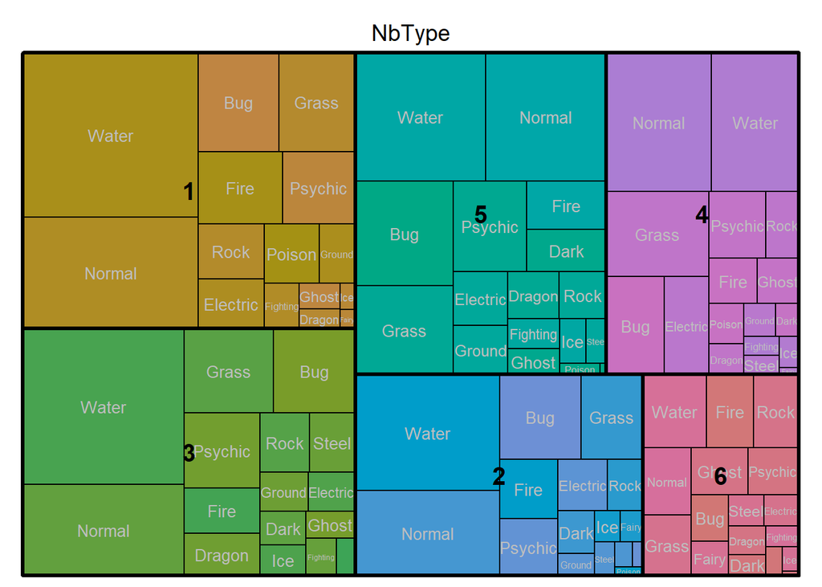

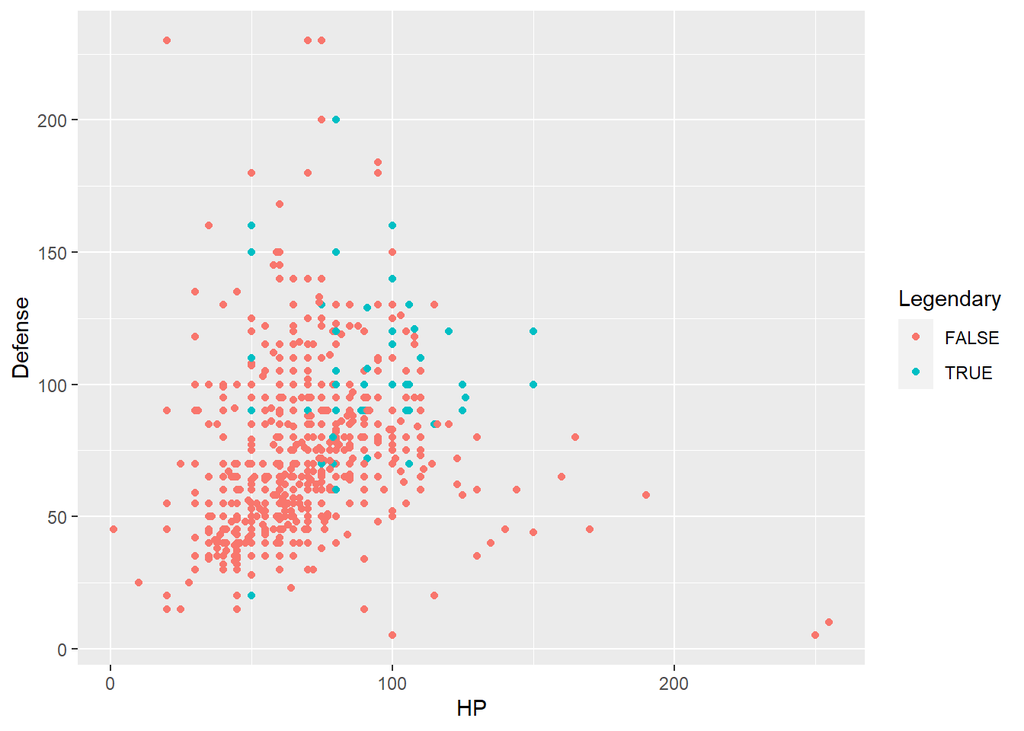

```r
  ggplot(pokemons, aes( HP, Defense, color=Legendary)) + geom_point()
```

On peut remarquer ici que les pokemons ayant beaucoup de HP ont généralement peut de défence, les quelques uns qui dérogent à la régle sont des pokemons légendaires.

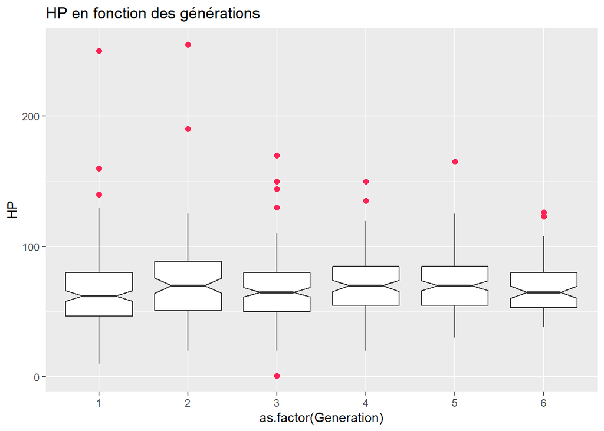

```r
ggplot(data = pokemons, aes(y=HP, x=as.factor(Generation))) + geom_boxplot(outlier.colour="#ff2255", outlier.shape=16, outlier.size=2, notch=TRUE) + labs(title="HP en fonction des générations")
```

A travers ces 6 générations les HP des pokemons se rapprochent tous de la meme moyenne, quasiment aucune divergence à noté. Il y a aussi quelque pokemon qui sortent du lot dans chaque generation.

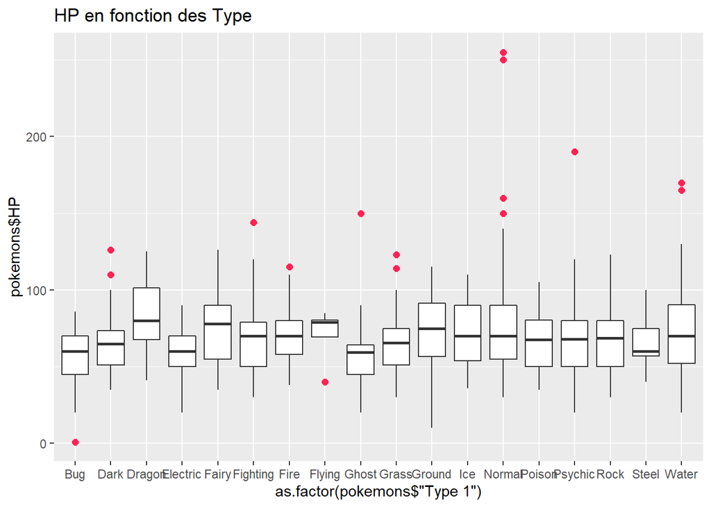

```r
ggplot(data = pokemons, aes(y=pokemons$HP, x=as.factor(pokemons$"Type 1"))) + geom_boxplot(outlier.colour="#ff2255", outlier.shape=16, outlier.size=2, notch=FALSE) + labs(title="HP en fonction des Type")
```

La répartitions des HP dans les differents type de pokemon est aussi sensiblement la même.

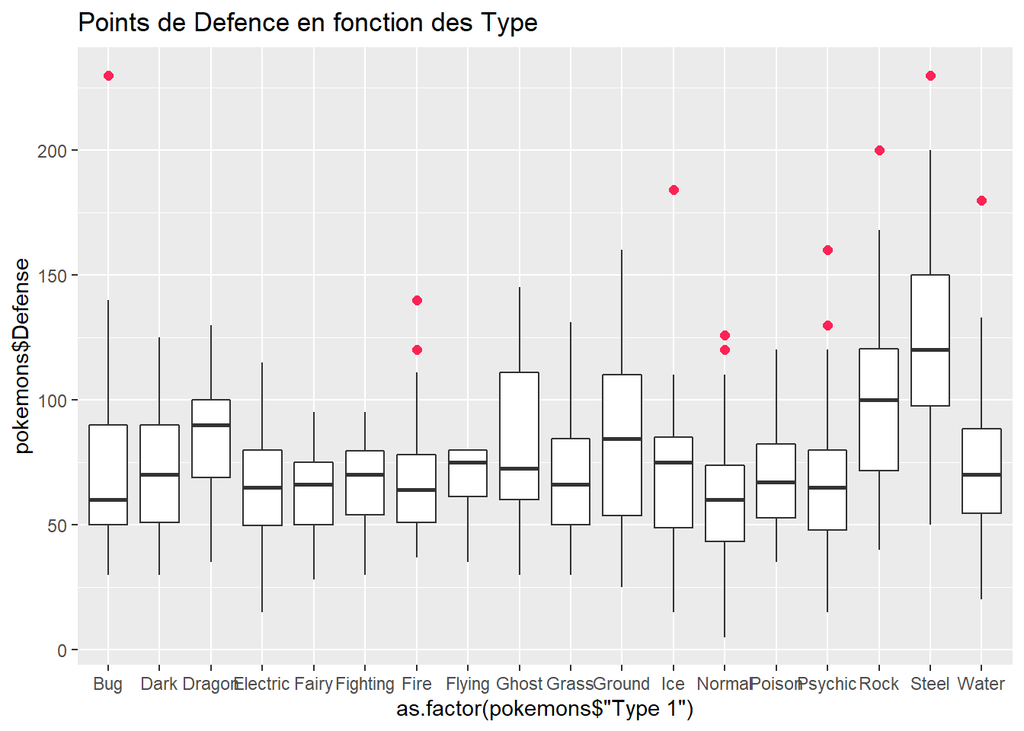

```r
ggplot(data = pokemons, aes(y=pokemons$Defense, x=as.factor(pokemons$"Type 1"))) + geom_boxplot(outlier.colour="#ff2255", outlier.shape=16, outlier.size=2, notch=FALSE) + labs(title="Points de Defence en fonction des Type")
```

Ici nous voyons clairement que les pokemons les plus defessif sont les pokemons de type Steel et Rock

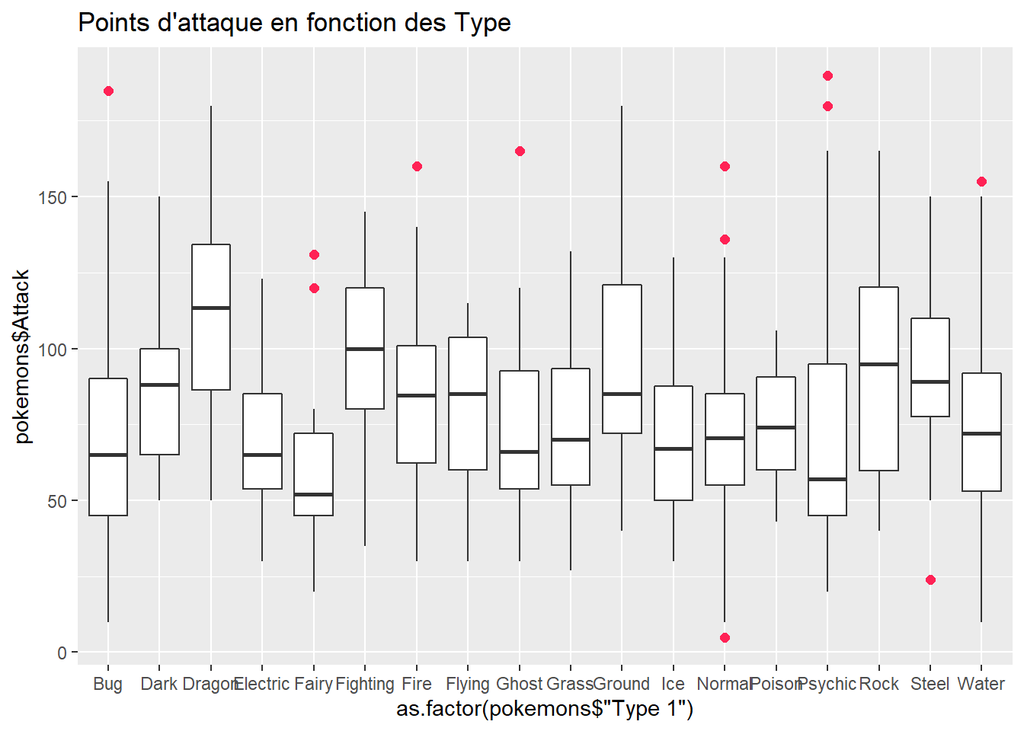

```r
ggplot(data = pokemons, aes(y=pokemons$Attack, x=as.factor(pokemons$"Type 1"))) + geom_boxplot(outlier.colour="#ff2255", outlier.shape=16, outlier.size=2, notch=FALSE) + labs(title="Points d'attaque en fonction des Type")
```

Ici nous voyons qu’en moyenne les pokemons avec le plus d’attaque sont les pokemon Dragon

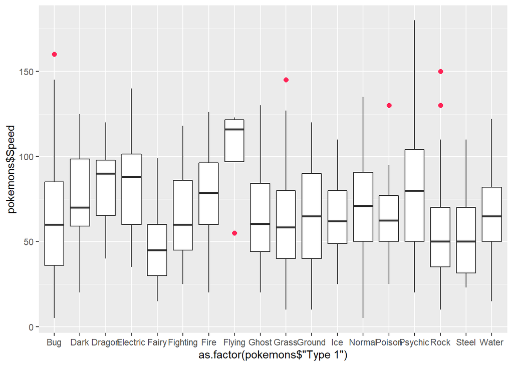

```r
ggplot(data = pokemons, aes(y=pokemons$Speed, x=as.factor(pokemons$"Type 1"))) + geom_boxplot(outlier.colour="#ff2255", outlier.shape=16, outlier.size=2, notch=FALSE)
```

Le Type Flying se demarque bien des autres concernant la vitesse.

## **II** Analyse de mon pokemon “favoris”

[figure not shown]

Mon pokemon favoris est **Squirtle**.  
Il est de type Water, possède : **44** HP, **65** points de Defense et **43** point de vitesse.

Comparons le avec les autres pokemons:

[figure not shown]

```r
ggplot(data = pokemons, aes(y=pokemons$HP, x=as.factor(pokemons$Generation))) + geom_boxplot(outlier.colour="#ff2255", outlier.shape=16, outlier.size=2, notch=TRUE) + geom_point(data=pokemon_fav, aes(y=pokemon_fav$HP, x=pokemon_fav$Generation), colour="red", size=5) + geom_text( aes(y = pokemon_fav$HP+10, x = pokemon_fav$Generation, label = pokemon_fav_Name)) + labs(title="Les HP de mon pokemon favoris par rapport au autres")
```

C’est moyen…

[figure not shown]

```r
  ggplot(pokemons, aes( HP, Defense)) + geom_point() + geom_point(data=pokemon_fav, aes(y=pokemon_fav$HP, x=pokemon_fav$Defense), colour="#ff0000", size=2) + geom_label( aes(y = pokemon_fav$HP-10, x = pokemon_fav$Defense, label = pokemon_fav_Name, colour="#ff0000", family = "Times New Roman")) + labs(title="Les HP et la defence de mon pokemon favoris par rapport au autres")
```

C’est même plutot faible.

[figure not shown]

```r
  ggplot(pokemons, aes( Attack, Speed)) + geom_point() + geom_point(data=pokemon_fav, aes(y=pokemon_fav$Attack, x=pokemon_fav$Speed), colour="#ff0000", size=2) + geom_label( aes(y = pokemon_fav$Attack-10, x = pokemon_fav$Speed, label = pokemon_fav_Name, colour="#ff0000", family = "Times New Roman")) + labs(title="Les vitesse et l'attaque de mon pokemon favoris par rapport au autres")
```

Décidement, pas grand chose à dire sur mon pokemon, je n’ai malheureusement pas de données sur la mignonitude des pokemons dans “pokemon.csv” :(

## **III** Battre Lugia

Dans cette dernière partie nous allons tenter de trouver un pokemon capable de battre Lugia !  
De plus cet objectif doit etre atteint avec deux contraintes : Le pokemon doit appartenir à la meme génération (la 2ème) et ne doit pas etre legendaire.

Récuperons donc les potentiels quandidats :

```r
candidats <- subset(pokemons, pokemons$Generation == Lugia$Generation & pokemons$Legendary == FALSE)
```

Nous avons donc 101 candidats potentiels

Il nous faut à present trouver un protocole pour les départager entres eux et ainsi pouvoir choisir le meilleurs candidats pour effectuer le combat.

Pour cela j’attribut un “score” à chaque pokemon. Ce score est calculé ainsi:  
Comme chaque compétences reflette les capacités du pokemon et comme plus elles sont elevé plus le pokemon est puissant j’additionne les competences du pokemon.

Cette technique est relativement simplisite, ameliorons là:  
S’il l’on considere que les HP, par expemple, n’ont que peut d’imporatance dans un combat alors il faut le refleter dans le score. c’est pourquoi j’ajoute à chaque compétence un coefficent allant de 0 (absolument insignifiante) à 1 (totalement indispensable).

Nous avons donc la formule suivante:

$score = \sum_{i=1}^{n}k_i*S_i$ avec $k_i =$ coefficient et $S_i =$ valeur de la statistique

J’ai fait le choix d’obpter pour ces coefficients pour la suite :  
K_HP <- 1  
K_ATT <- 1  
K_DEF <- 1  
K_SPA <- 0.7  
K_SPD <- 0.7  
K_SPEED <- 0.8

[figure not shown]

[figure not shown]

Comparons le score de  
mon pokemon favoris Squirtle : **271.2**  
avec celui de Lugia : **584.8**  
*on imagine déjà l’issue du combat* **D:**

Appliquons le score a tout les candidats

```r
candidats <- cbind(candidats, c(rep(0, dim(candidats)[1])))
colnames(candidats)[13] <- "score"

for (nb in 1:dim(candidats)[1]) {
  candidats[nb,]$"score" <- compute_score(candidats[nb,])
}
```

Le score moyen de nos candidats est **355.5277228**.

A present regardons ceux qui ont un score proche et supérieur à Lugia (**584.8**):

```r
bests <- subset(candidats, candidats$score >= compute_score(Lugia)-(compute_score(Lugia)/10))
printable_bests <- data.frame(bests$Name, bests$`score`, bests$`Type 1`, bests$`Type 2`, bests$HP, bests$Attack, bests$Defense, bests$`Sp. Atk`, bests$`Sp. Def`, bests$Speed)
colnames(printable_bests) <- c("Name", "Score", "Type 1", "Type 2", "HP", "Attack", "Defense", "Sp. A", "Sp. D", "Speed")
kable(printable_bests)
```

| Name | Score | Type 1 | Type 2 | HP | Attack | Defense | Sp. A | Sp. D | Speed |
| --- | --- | --- | --- | --- | --- | --- | --- | --- | --- |
| Mega Steelix | 559.0 | Steel | Ground | 75 | 125 | 230 | 55 | 95 | 30 |
| Mega Scizor | 535.5 | Bug | Steel | 70 | 150 | 140 | 65 | 100 | 75 |
| Mega Heracross | 541.5 | Bug | Fighting | 80 | 185 | 115 | 40 | 105 | 75 |
| Tyranitar | 529.3 | Rock | Dark | 100 | 134 | 110 | 95 | 100 | 61 |
| Mega Tyranitar | 621.3 | Rock | Dark | 100 | 164 | 150 | 95 | 120 | 71 |

Pour ne garder que les pokemons qui ont vraiment une chance, ne gardons que les pokemons dont le type est fort contre le type de Lugia (Psychic, Flying) soit : Dark, Electric, Ghost, Ice, Rock

```r
lasts <- subset(printable_bests, printable_bests$"Type 1" == "Dark" | printable_bests$"Type 1" == "Electric" | printable_bests$"Type 1" == "Ghost" | printable_bests$"Type 1" == "Ice" | printable_bests$"Type 1" == "Rock" )
kable(lasts)
```

|  | Name | Score | Type 1 | Type 2 | HP | Attack | Defense | Sp. A | Sp. D | Speed |
| --- | --- | --- | --- | --- | --- | --- | --- | --- | --- | --- |
| 4 | Tyranitar | 529.3 | Rock | Dark | 100 | 134 | 110 | 95 | 100 | 61 |
| 5 | Mega Tyranitar | 621.3 | Rock | Dark | 100 | 164 | 150 | 95 | 120 | 71 |

Il ne reste que 2 pokemon potentielement capable de vaincre Lugia. Et un seul avec un score plus élevé : Mega Tyranitar. Il semble donc tout indiqué d’utiliser ce pokemon pour ce gagner combat !

[figure not shown]

[figure not shown]